# EDLD 610 Winter 2020 Project Proposal

Jim Wright

1/28/2020

# Data Description:

The data to be used for this project consists of five data sets from the FiveThirtyEight GitHub page. (https://github.com/fivethirtyeight/data/tree/master/college-majors). All data is from American Community Survey 2010-2012 Public Use Microdata Series.

# Information from the FiveThirtyEight GitHub page on the data:

## recent-grads.csv (ages <28)

## grad-students.csv (ages 25+)

All contain basic earnings and labor force information. recent-grads.csv contains a more detailed breakdown, including by sex and by the type of job they got. grad-students.csv contains details on graduate school attendees.

Additionally, women-stem.csv contains data for scatter plot in associated DataLab post on women in science/technology jobs. It is a subset of recent-grads.csv. (Small easter egg: Check out my related Shiny app: https://bencasselman.shinyapps.io/new-test/)

The information presented above is copied directly from the FiveThirtyEight GitHub repo.

# Plot Ideas

To complete my project, I intend to practice using the joins() function to merge comparable data sets. All data sets with the exception of the majors_lists data set have comparable columns that will be useful to merge together. The recent-grads.csv data set will most likely be the data set I use the most to produce plots intended for an audience that works in both educational administration and labor relations on trends in employment rate and type of major for recent college graduates.

```
## # A tibble: 6 x 11
##   Major_code Major Major_category  Total Employed Employed_full_t…
##        <int> <chr> <chr>           <int>    <int>            <int>
## 1       1100 GENE… Agriculture &… 128148    90245            74078
## 2       1101 AGRI… Agriculture &…  95326    76865            64240
## 3       1102 AGRI… Agriculture &…  33955    26321            22810
## 4       1103 ANIM… Agriculture &… 103549    81177            64937
## 5       1104 FOOD… Agriculture &…  24280    17281            12722
## 6       1105 PLAN… Agriculture &…  79409    63043            51077
## # … with 5 more variables: Unemployed <int>, Unemployment_rate <dbl>,
## #   Median <int>, P25th <int>, P75th <dbl>
```

```
## # A tibble: 6 x 22
##   Major_code Major Major_category Grad_total Grad_sample_size Grad_employed
##        <int> <chr> <chr>               <int>            <int>         <int>
## 1       5601 CONS… Industrial Ar…       9173              200          7098
## 2       6004 COMM… Arts                53864              882         40492
## 3       6211 HOSP… Business            24417              437         18368
## 4       2201 COSM… Industrial Ar…       5411               72          3590
## 5       2001 COMM… Computers & M…       9109              171          7512
## 6       3201 COUR… Law & Public …       1542               22          1008
## # … with 16 more variables: Grad_full_time_year_round <int>,
## #   Grad_unemployed <int>, Grad_unemployment_rate <dbl>,
## #   Grad_median <dbl>, Grad_P25 <int>, Grad_P75 <dbl>,
## #   Nongrad_total <int>, Nongrad_employed <int>,
## #   Nongrad_full_time_year_round <int>, Nongrad_unemployed <int>,
## #   Nongrad_unemployment_rate <dbl>, Nongrad_median <dbl>,
## #   Nongrad_P25 <int>, Nongrad_P75 <dbl>, Grad_share <dbl>,
## #   Grad_premium <dbl>
```

```
## # A tibble: 6 x 3
##   FOD1P Major                                Major_Category
##   <chr> <chr>                                <chr>
## 1 1100  GENERAL AGRICULTURE                  Agriculture & Natural Resourc…
## 2 1101  AGRICULTURE PRODUCTION AND MANAGEME… Agriculture & Natural Resourc…
## 3 1102  AGRICULTURAL ECONOMICS               Agriculture & Natural Resourc…
## 4 1103  ANIMAL SCIENCES                      Agriculture & Natural Resourc…
## 5 1104  FOOD SCIENCE                         Agriculture & Natural Resourc…
## 6 1105  PLANT SCIENCE AND AGRONOMY           Agriculture & Natural Resourc…
```

```
## # A tibble: 6 x 21
##    Rank Major_code Major Total   Men Women Major_category ShareWomen
##   <int>      <int> <chr> <int> <int> <int> <chr>               <dbl>
## 1     1       2419 PETR…  2339  2057   282 Engineering         0.121
## 2     2       2416 MINI…   756   679    77 Engineering         0.102
## 3     3       2415 META…   856   725   131 Engineering         0.153
## 4     4       2417 NAVA…  1258  1123   135 Engineering         0.107
## 5     5       2405 CHEM… 32260 21239 11021 Engineering         0.342
## 6     6       2418 NUCL…  2573  2200   373 Engineering         0.145
## # … with 13 more variables: Sample_size <int>, Employed <int>,
## #   Full_time <int>, Part_time <int>, Full_time_year_round <int>,
## #   Unemployed <int>, Unemployment_rate <dbl>, Median <int>, P25th <int>,
## #   P75th <int>, College_jobs <int>, Non_college_jobs <int>,
## #   Low_wage_jobs <int>
```

```
## # A tibble: 6 x 9
##    Rank Major_code Major Major_category Total   Men Women ShareWomen Median
##   <int>      <int> <chr> <chr>          <int> <int> <int>      <dbl>  <int>
## 1     1       2419 PETR… Engineering     2339  2057   282      0.121 110000
## 2     2       2416 MINI… Engineering      756   679    77      0.102  75000
## 3     3       2415 META… Engineering      856   725   131      0.153  73000
## 4     4       2417 NAVA… Engineering     1258  1123   135      0.107  70000
## 5     5       2418 NUCL… Engineering     2573  2200   373      0.145  65000
## 6     6       2405 CHEM… Engineering    32260 21239 11021      0.342  65000
```

[output not shown]

[output cut: 158 more lines]

```
## # A tibble: 16 x 2
##    Major_category                          n
##    <chr>                               <int>
##  1 Agriculture & Natural Resources        10
##  2 Arts                                    8
##  3 Biology & Life Science                 14
##  4 Business                               13
##  5 Communications & Journalism             4
##  6 Computers & Mathematics                11
##  7 Education                              16
##  8 Engineering                            29
##  9 Health                                 12
## 10 Humanities & Liberal Arts              15
## 11 Industrial Arts & Consumer Services     7
## 12 Interdisciplinary                       1
## 13 Law & Public Policy                     5
## 14 Physical Sciences                      10
## 15 Psychology & Social Work                9
## 16 Social Science                          9
```

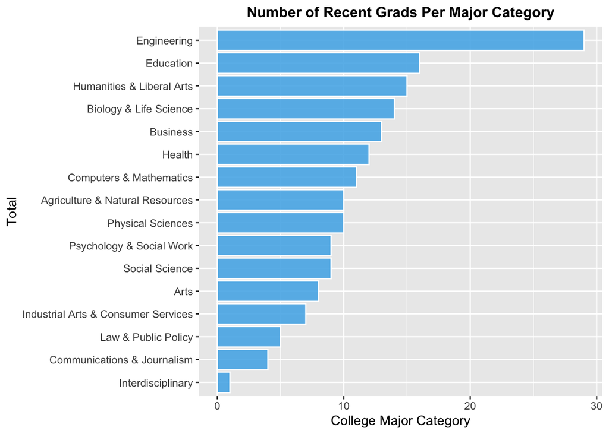

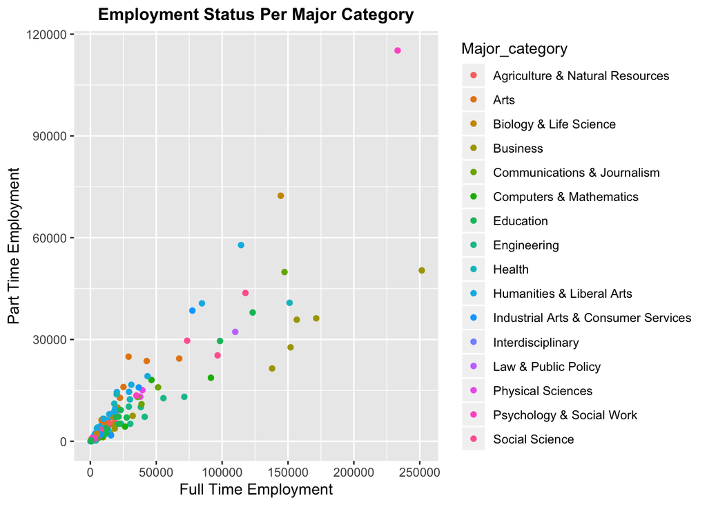

[output not shown]

[output cut: 158 more lines]

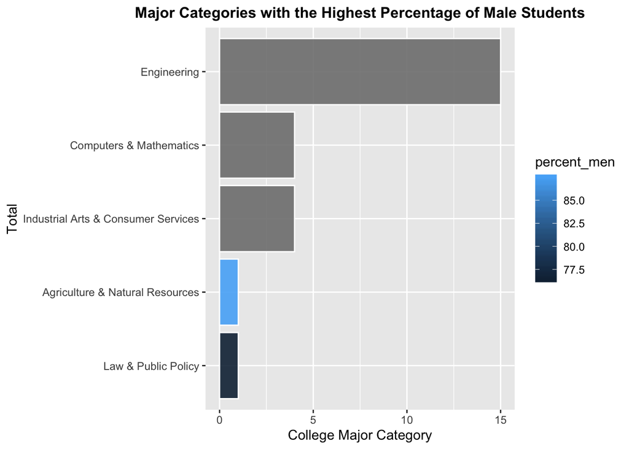

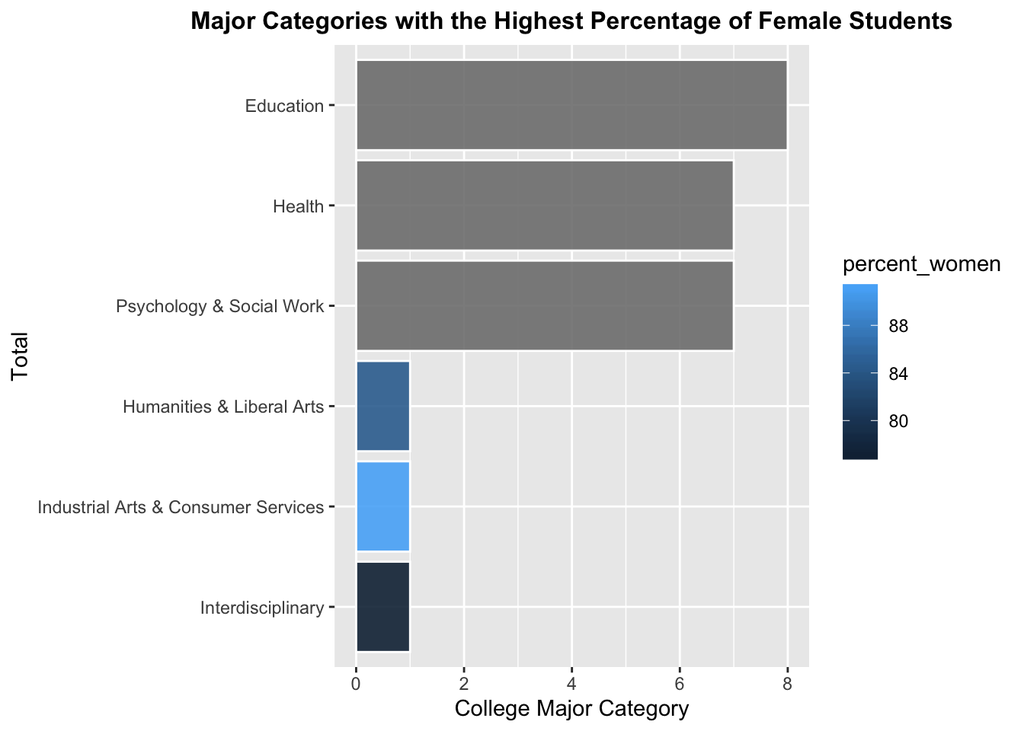

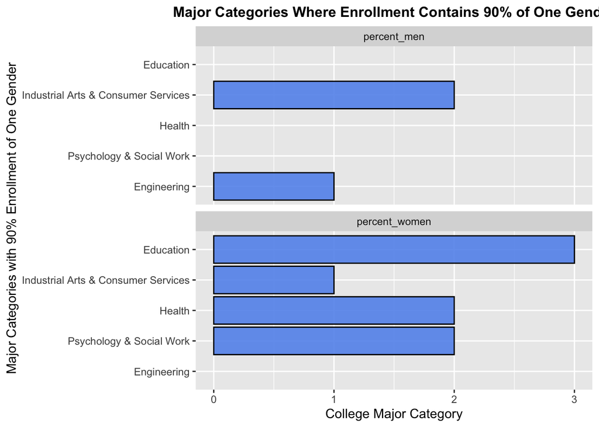

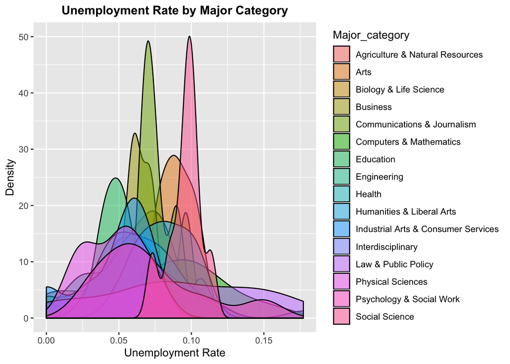

# Plot Ideas Followup

After taking time to play with the data sets for this project, I think the recent-grads data set will primarily be my main data set to work with to make plots specifically exploring unemployment rate and the distribution of college major categories by gender. My initial plot ideas will require much more detail and editing, but I think they provide an opportunity to utilize dplyr and tidyr commands learned from the first course combined with ggplot skills learned this term.